# An R Markdown document converted from “C://Users//nzoro//OneDrive//Documents//Esilv//Actuariat//R_Cours//apercu_Projet_R.ipynb”

- Nous allons donc analyser le choix des différentes formules et des comparateurs en fonction du nombre d’enfants de chaque client, pour ainsi voir si le nombre d’enfants influence le choix de la formule.

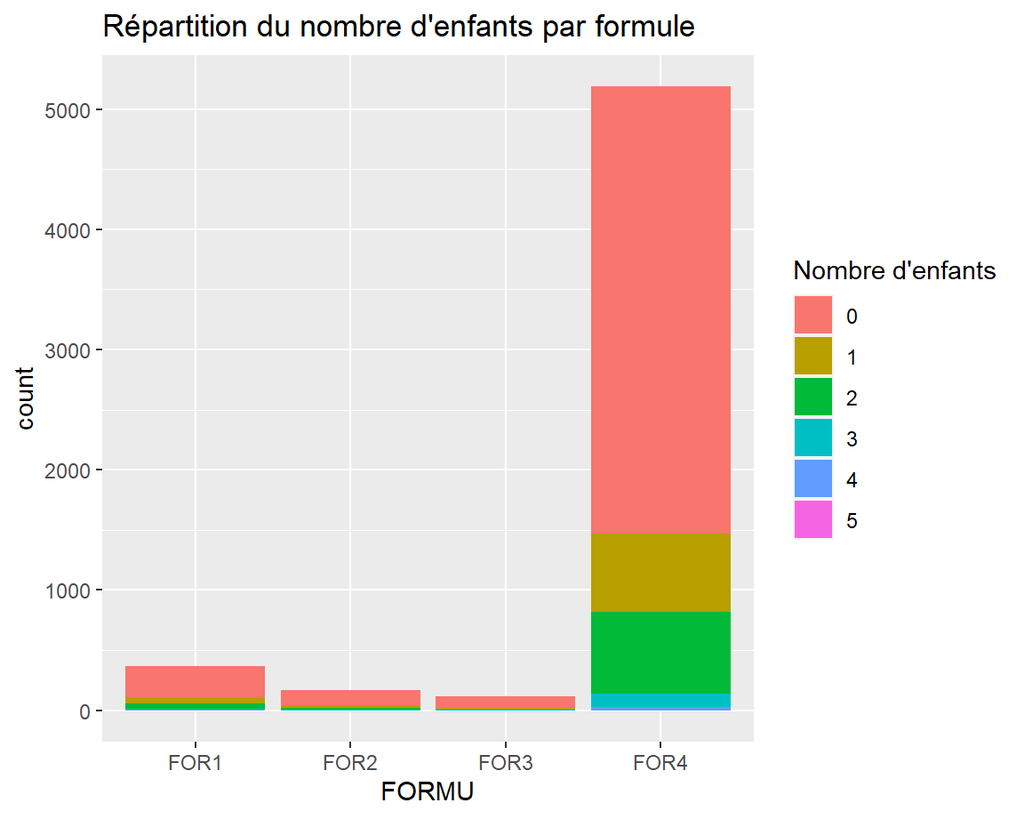

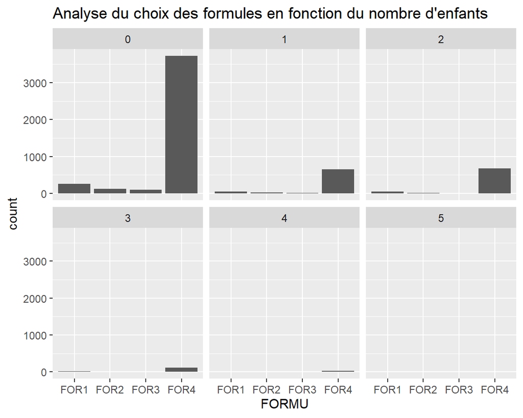

**Interprétation :**

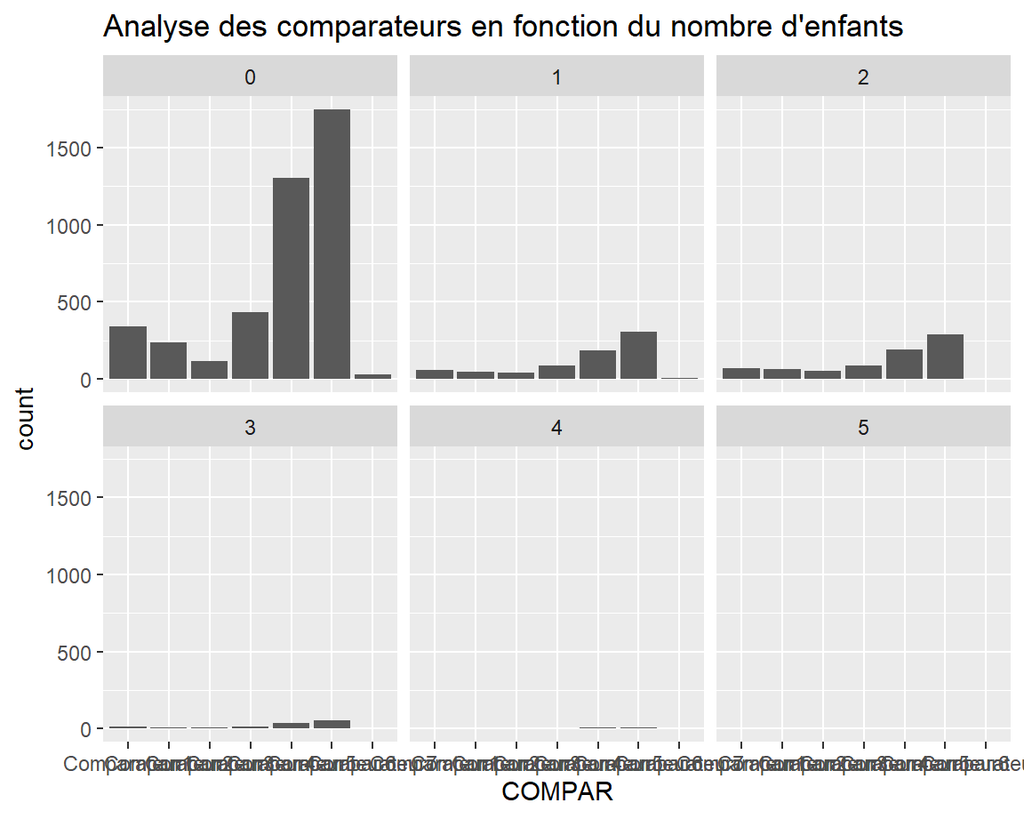

**Interprétation:**

Le nombre d’enfants des clients n’a pas influencé le fait que la plus grande partie de nos assurés aient souscrit via les comparateurs 6 et 5.

### 4. Durée des contrats

```
FALSE
 5836
```

Tous les contrats possèdent une date d’effet de garantie

```
FALSE  TRUE
 1149  4687
```

Il y’a 4687 contrats sans date de résiliation et 1149 contrats résiliés

```
 Non  Oui
4687 1149
```

- Création de la variable représentant la durée des contrats pour les contrats qui ont été résiliés

```
           IDPOL    DATEEFF      IDCLI     IDPART     IDCHI1     IDCHI2 IDCHI3
   1: 2C7EAEF380 2011-02-10 7A61ADDB61       <NA>       <NA>       <NA>   <NA>
   2: F1125A72F9 2011-07-10 4E5D3AA63C 32D5615B20 2EF179B6C7 B09D69E316   <NA>
   3: 0F5BF8EA40 2011-08-10 283B50C751       <NA>       <NA>       <NA>   <NA>
   4: 73FB728155 2011-08-10 2DF3A65E55       <NA>       <NA>       <NA>   <NA>
   5: 21BFCE62CB 2012-01-01 9C968CCD1F       <NA>       <NA>       <NA>   <NA>
  ---
1145: CD2B50E2C8 2015-01-01 0459108AB7       <NA>       <NA>       <NA>   <NA>
1146: 75B344BC5B 2015-01-01 7BD50DF5BD 8C1E9ADB9E E3EBF67A08 0B47EABB20   <NA>
1147: 393975A549 2015-01-01 4C7F9A4B88       <NA>       <NA>       <NA>   <NA>
1148: DA3E2F195B 2015-01-01 E8E1D8AB93       <NA>       <NA>       <NA>   <NA>
1149: A240758C99 2015-01-01 66D9A5E612       <NA>       <NA>       <NA>   <NA>
      IDCHI4 IDCHI5 IDCHI6 FORMU    DATECAN
   1:   <NA>   <NA>     NA  FOR1 2017-12-31
   2:   <NA>   <NA>     NA  FOR4 2016-12-31
   3:   <NA>   <NA>     NA  FOR2 2016-12-31
   4:   <NA>   <NA>     NA  FOR3 2016-12-31
   5:   <NA>   <NA>     NA  FOR4 2016-12-31
  ---
1145:   <NA>   <NA>     NA  FOR4 2015-01-13
1146:   <NA>   <NA>     NA  FOR1 2014-01-13
1147:   <NA>   <NA>     NA  FOR4 2014-01-13
1148:   <NA>   <NA>     NA  FOR2 2013-01-13
1149:   <NA>   <NA>     NA  FOR4 2013-01-13
                                         REACAN AMTPREM RANKAGG       COMPAR
   1:                Non-payment of the premium    1455       1 Comparateur1
   2:                Non-payment of the premium    4242       4 Comparateur1
   3:                Non-payment of the premium    1977       1 Comparateur1
   4:                Non-payment of the premium    3628       2 Comparateur1
   5:                Non-payment of the premium    4738       2 Comparateur1
  ---
1145:                Non-payment of the premium    3680      NA Comparateur1
1146:                     Cancel renewal policy    4794      NA Comparateur2
1147:                     Cancel renewal policy    1631      NA Comparateur2
1148:                Non-payment of the premium    1801      NA Comparateur2
1149: Cancellation on renewal from the customer    3802      NA Comparateur4
                    MARCLI SEXCLI     DTNCLI            PROFCLI    CP SEXCJ
   1:               Single      M 1980-12-16           Employee 29200  <NA>
   2:              Married      M 1968-12-22           Employee  1700     F
   3:               Single      M 1977-06-08           Employee 45260  <NA>
   4:               Single      M 1960-09-05           Employee 74130  <NA>
   5:               Single      F 1951-02-19            Retired 14600  <NA>
  ---
1145:               Single      M 1955-01-13            Retired 95220  <NA>
1146:    Cohabitant / Pacs      F 1969-07-16           Employee 29470     M
1147:               Single      M 1990-12-01 Without profession 13011  <NA>
1148: Separated / Divorced      M 1961-09-17 Without profession 67200  <NA>
1149:               Single      F 1968-04-05           Employee 34560  <NA>
           DTNCJ             PROFCJ nombre_enfants resilie
   1:       <NA>               <NA>              0     Oui
   2: 1978-11-15           Employee              2     Oui
   3:       <NA>               <NA>              0     Oui
   4:       <NA>               <NA>              0     Oui
   5:       <NA>               <NA>              0     Oui
  ---
1145:       <NA>               <NA>              0     Oui
1146: 1966-11-28 Without profession              2     Oui
1147:       <NA>               <NA>              0     Oui
1148:       <NA>               <NA>              0     Oui
1149:       <NA>               <NA>              0     Oui
```

```
Time differences in days
[1] 2516 2001 1970 1970 1826 1848
```

```
        IDPOL    DATEEFF      IDCLI     IDPART     IDCHI1     IDCHI2 IDCHI3
1: 2C7EAEF380 2011-02-10 7A61ADDB61       <NA>       <NA>       <NA>   <NA>
2: F1125A72F9 2011-07-10 4E5D3AA63C 32D5615B20 2EF179B6C7 B09D69E316   <NA>
3: 0F5BF8EA40 2011-08-10 283B50C751       <NA>       <NA>       <NA>   <NA>
4: 73FB728155 2011-08-10 2DF3A65E55       <NA>       <NA>       <NA>   <NA>
5: 21BFCE62CB 2012-01-01 9C968CCD1F       <NA>       <NA>       <NA>   <NA>
6: 0EF51BD7B0 2011-12-10 51305185AA       <NA>       <NA>       <NA>   <NA>
   IDCHI4 IDCHI5 IDCHI6 FORMU    DATECAN                     REACAN AMTPREM
1:   <NA>   <NA>     NA  FOR1 2017-12-31 Non-payment of the premium    1455
2:   <NA>   <NA>     NA  FOR4 2016-12-31 Non-payment of the premium    4242
3:   <NA>   <NA>     NA  FOR2 2016-12-31 Non-payment of the premium    1977
4:   <NA>   <NA>     NA  FOR3 2016-12-31 Non-payment of the premium    3628
5:   <NA>   <NA>     NA  FOR4 2016-12-31 Non-payment of the premium    4738
6:   <NA>   <NA>     NA  FOR4 2016-12-31 Non-payment of the premium    4320
   RANKAGG       COMPAR  MARCLI SEXCLI     DTNCLI  PROFCLI    CP SEXCJ
1:       1 Comparateur1  Single      M 1980-12-16 Employee 29200  <NA>
2:       4 Comparateur1 Married      M 1968-12-22 Employee  1700     F
3:       1 Comparateur1  Single      M 1977-06-08 Employee 45260  <NA>
4:       2 Comparateur1  Single      M 1960-09-05 Employee 74130  <NA>
5:       2 Comparateur1  Single      F 1951-02-19  Retired 14600  <NA>
6:       6 Comparateur1  Single      F 1962-07-12 Employee 66600  <NA>
        DTNCJ   PROFCJ nombre_enfants resilie dureeContra
1:       <NA>     <NA>              0     Oui   2516 days
2: 1978-11-15 Employee              2     Oui   2001 days
3:       <NA>     <NA>              0     Oui   1970 days
4:       <NA>     <NA>              0     Oui   1970 days
5:       <NA>     <NA>              0     Oui   1826 days
6:       <NA>     <NA>              0     Oui   1848 days
```

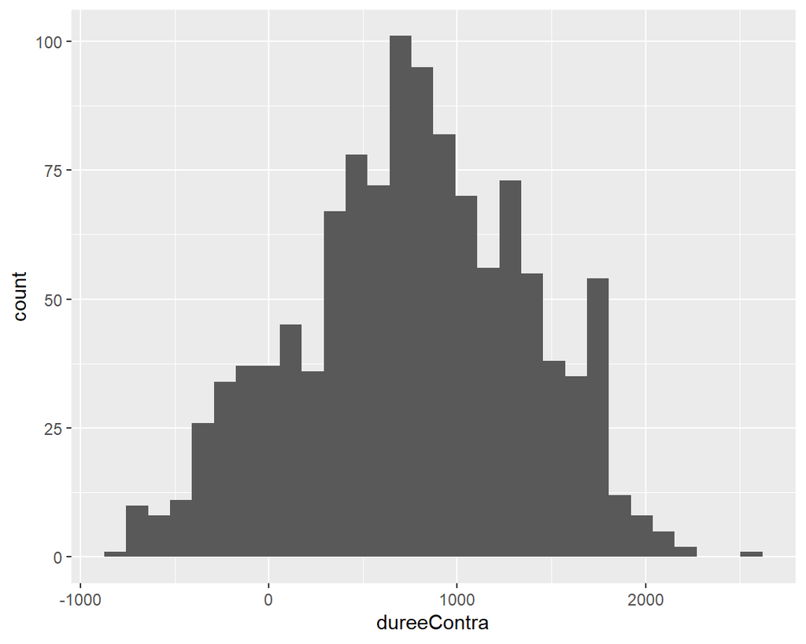

Remarque:

Il y’a des dates négatives, qui ne sont pas conformes. Il faut les retirer de la base de données.

```
Time differences in days
[1] -320 -144  -46  -46  -47 -366
```